## Electricity Data Cleaning

Data source: [UN Data](http://data.un.org/Explorer.aspx)

### Load libraries and read in data

3 files were created with additional codes and labels. These files were used to aggregate country data into regions, format country names, add a shorter description to the ‘Transaction’, and add labels requiered for our visualization.

```r
# Load libraries
library(reshape2)
library(plyr)

# Read input files
# Electricity raw data
raw_data <- read.csv( "electricity_raw_data.csv", stringsAsFactors=FALSE)

# The following .csv files were created to clean and add lables to the raw data
# grouping of countries according to UN Regions
country <- read.csv( "codes_country.csv", stringsAsFactors=FALSE)
# shorter description for the column 'transaction'
description <- read.csv( "codes_description.csv", stringsAsFactors=FALSE)
# Labels for categories of the visualization
categories <- read.csv( "codes_categories.csv", stringsAsFactors=FALSE)
```

### Clean Data

- Shorten description of units from ‘Kilowatt-hours, million’ to ‘million kWh’
- Make all missing values (NA) 0
- Format country names in ‘country’ data frame to match the country names in raw_data

Join the following countries together:

- Czech Republic with Czechoslovakia (former)
- Ethiopia with Ethiopia,incl.Eritrea
- Germany with German D.R.(former) and Germany(Fed.Rep.)
- Russian Federation with USSR (former)
- Serbia with Serbia and Montenegro
- Yemen with Yemen (former) and Dem. Yemen (former)

And remove the following countries:

- Yugoslavia, SFR
- Other Asia
- Pacific Islands (Trust Territory)

Grouped countries by region according to the [United Nations Statistics Division](http://unstats.un.org/unsd/methods/m49/m49regin.htm).

The final dataset contains the following aggregates: sub-continents, continents, world (all countries), and develop/developing countries.

The sub-continents are:

- Eastern Africa
- Middle Africa
- Northern Africa
- Southern Africa
- Western Africa
- Caribbean
- Central America
- South America
- Northern America
- Central Asia
- Eastern Asia
- Southern Asia
- South-Eastern Asia
- Western Asia
- Eastern Europe
- Northern Europe
- Southern Europe
- Western Europe
- Australia and New Zealand
- Melanesia
- Micronesia
- Polynesia

The continents are:

- Africa
- Americas
- Asia
- Europe
- Oceania

And finally, the categories and aggregates that were missing for the visualization were added.

The final data set looks like this:

```
##   Description      Type    category1    category2         Country Year
## 1        agri cons_side sub_consumed sub_consumed            Chad 1995
## 2        agri cons_side sub_consumed sub_consumed China Macao SAR 1995
## 3        agri cons_side sub_consumed sub_consumed    Central Asia 1995
## 4        agri cons_side sub_consumed sub_consumed           Gabon 1995
## 5        agri cons_side sub_consumed sub_consumed          Zambia 1994
## 6        agri cons_side sub_consumed sub_consumed Central America 1995
##          Unit population value
## 1 million kWh       6980     0
## 2 million kWh          0     0
## 3 million kWh      53065 33764
## 4 million kWh       1080     0
## 5 million kWh       8625   200
## 6 million kWh     127818  7027
```

Some final notes:

- ‘Country’ contains groups like ‘world’, ‘Africa’, and ‘developing’ which are not really countries.
- Nuclear was grouped as ‘Non-Renewable’
- I did not aggregate renewable and non-renewable categories

And the category heirarchy is as follows:

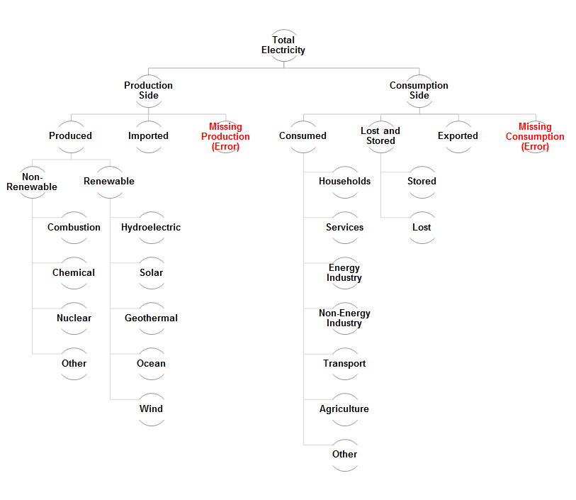

### Write Cleaned Data

```r
write.csv(data, file = "electricity_data.csv",row.names=FALSE)
```